# Capstone Milestone Report

Rhowell

2022-11-29

## Summary

This is the Milestone Report for the John Hopkins University’s Data Science Specialization Capstone offered by Coursera. The Capstone consists of creating a predictive text generator based off of corpa of text from SwiftKey. This Milestone Report will read the corpa, preform basic explanatory data analysis, and finally describe several ways forward for the final predictive text model.

## Load the Data

```r
train_url <- "https://d396qusza40orc.cloudfront.net/dsscapstone/dataset/Coursera-SwiftKey.zip"
train_data_file <- "data/Coursera-SwiftKey.zip"

if (!file.exists('data')) {
    dir.create('data')
}
if (!file.exists("data/final/en_US")) {
    tempFile <- tempfile()
    download.file(train_url, tempFile)
    unzip(tempFile, exdir = "data")
    unlink(tempFile)
}

# blogs
blogs_file_name <- "data/final/en_US/en_US.blogs.txt"
con <- file(blogs_file_name, open = "r")
blogs <- readLines(con, encoding = "UTF-8", skipNul = TRUE)
close(con)

# news
news_file_name <- "data/final/en_US/en_US.news.txt"
con <- file(news_file_name, open = "r")
news <- readLines(con, encoding = "UTF-8", skipNul = TRUE)
close(con)

# twitter
twitter_file_name <- "data/final/en_US/en_US.twitter.txt"
con <- file(twitter_file_name, open = "r")
twitter <- readLines(con, encoding = "UTF-8", skipNul = TRUE)
close(con)

rm(con)
```

## Exploratory Data Analysis

Initially the corpa are in three files, one each for Twitter, news, and blogs. I will combine them into a single corpus as well as tidy some of the text.

### Basic Exploratory Summary

Let us first explore the three separate files to find basic summaries of the three files, including word counts, line counts and basic data tables.

| File | FileSize | Lines | Characters | Words | WPL.Min | WPL.Median | WPL.Max |
| --- | --- | --- | --- | --- | --- | --- | --- |
| en_US.blogs.txt | 200 MB | 899288 | 206824505 | 37570839 | 0 | 28 | 6726 |
| en_US.news.txt | 196 MB | 1010242 | 203223159 | 34494539 | 1 | 32 | 1796 |
| en_US.twitter.txt | 159 MB | 2360148 | 162096241 | 30451170 | 1 | 12 | 47 |

### Density Plot of Words Per Line

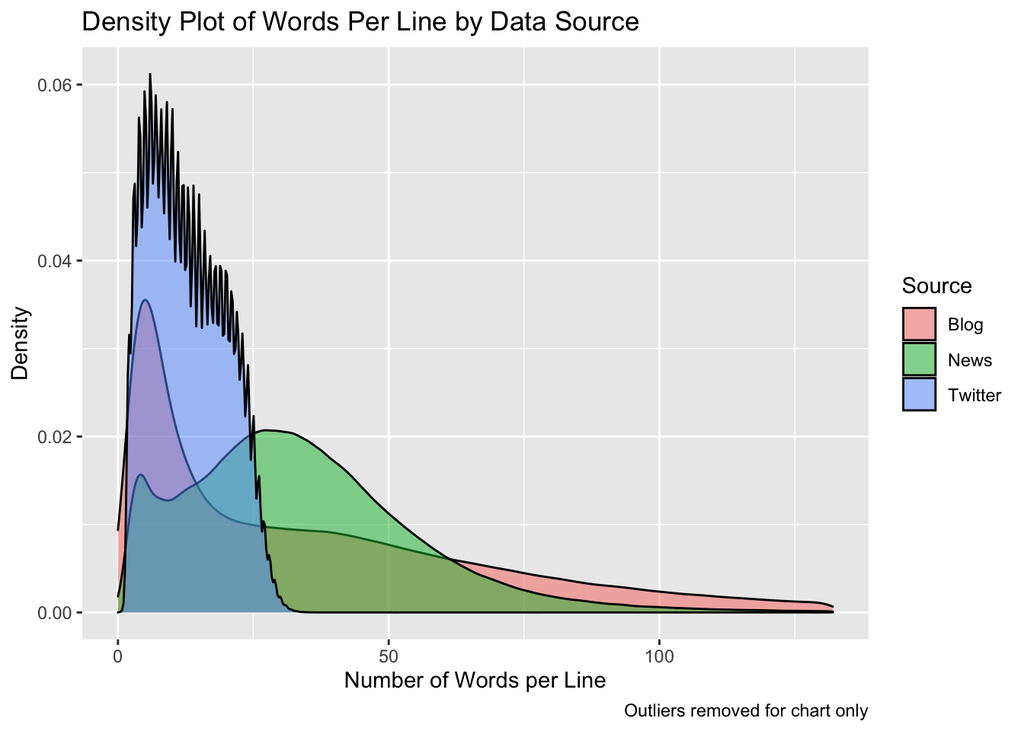

```r
library(reshape2)
library(dplyr)
library(ggplot2)

long_wpl <- melt(wpl, id="x") %>%
  mutate(L1 = as.factor(L1))

ggplot(data = long_wpl)+
  geom_density(aes(x = value, fill = L1), alpha = 0.5, outlier.shape = NA) +
  scale_fill_discrete(name = "Source", labels=c('Blog', 'News', 'Twitter')) +
  scale_x_continuous(limits = quantile(long_wpl$value, c(0, 0.99))) +
  labs(title = "Density Plot of Words Per Line by Data Source", caption = "Outliers removed for chart only") +
  xlab("Number of Words per Line") +
  ylab("Density")
```

## Data Preparation

The data sources will be sampled at 1% to train the predictive model more effectively.

```r
# set seed
set.seed(424242)

# sample the sources
sample_blogs <- sample(blogs, length(blogs) * 0.01, replace = FALSE)
sample_news <- sample(news, length(news) * 0.01, replace = FALSE)
sample_twitter <- sample(twitter, length(twitter) * 0.01, replace = FALSE)

# remove all non-English characters from the sampled data
sample_blogs <- iconv(sample_blogs, "latin1", "ASCII", sub = "")
sample_news <- iconv(sample_news, "latin1", "ASCII", sub = "")
sample_twitter <- iconv(sample_twitter, "latin1", "ASCII", sub = "")

# merge into one dataframe
sample_data <- c(sample_blogs, sample_news, sample_twitter)
```

The data will now be cleaned and merged into a single corpus for use by the text predictor model later.

```r
library(tm)
library(sentimentr)

corpus <- VCorpus(VectorSource(sample_data))  # Build corpus
toSpace <- content_transformer(function(x, pattern) gsub(pattern, " ", x))  # Space converter function
corpus <- tm_map(corpus, toSpace, "(f|ht)tp(s?)://(.*)[.][a-z]+")  # Mutate URLs to spaces
corpus <- tm_map(corpus, toSpace, "@[^\\s]+")  # Mutate Twitter handles to spaces
corpus <- tm_map(corpus, toSpace, "\\b[A-Z a-z 0-9._ - ]*[@](.*?)[.]{1,3} \\b")  # Mutate email patterns to spaces
corpus <- tm_map(corpus, tolower)  # Convert all words to lowercase
corpus <- tm_map(corpus, removeWords, stopwords("english"))  # Remove common English stop words
corpus <- tm_map(corpus, removePunctuation)  # Remove punctuation marks
corpus <- tm_map(corpus, removeNumbers)  # Remove numbers
corpus <- tm_map(corpus, stripWhitespace)  # Trim whitespace
corpus <- tm_map(corpus, removeWords, lexicon::profanity_arr_bad)  # Remove profanity
corpus <- tm_map(corpus, PlainTextDocument)  # Convert to plain text documents

# Display first 10 observations from single corpus
corpus_text <- data.frame(text = unlist(sapply(corpus, '[', "content")), stringsAsFactors = FALSE)
kable(tail(corpus_text$text, 10),
      row.names = FALSE,
      col.names = NULL,
      align = c("l"),
      caption = "First 10 Documents") %>%
        kable_styling(position = "left")
```

| allergic plums break rash face eat stop eating |
| --- |
| thanks follow dawn |
| thank cari wish many great weeks |
| best work years grey treasure |
| product engineering session missed |
| happy birthday babyy changed lifes much proud u congrats |
| indeed sooner wife can land interview dartmouth |
| know nagra sts former landlord vashon prop master wonder years much cool junk |
| thingsthatannoyme last one going sleep clean face waking big red pimple |
| know gonna haut gonna need pic u totheter u know u one u sent u g wheni |

## Data Features of Tokenization by N-gram

Next in the exploratory data analysis is looking at tokenization by n-gram.

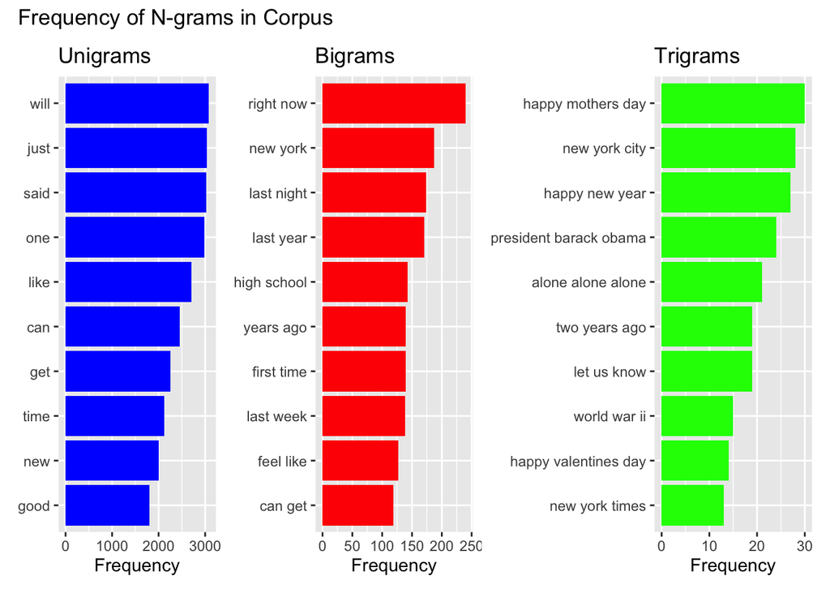

```r
library(dplyr)
library(tidyr)
library(tidytext)
library(patchwork)

corpus_text_tibble <- tibble(line = 1:nrow(corpus_text), text = corpus_text$text)

corpus_text_unigram <- corpus_text_tibble %>%
  unnest_tokens(word, text) %>%
  count(word, sort = TRUE) %>%
  top_n(10) %>%
  ggplot() +
  geom_col(aes(n, reorder(word, n)), fill = "blue") +
  labs(title = "Unigrams") +
  ylab(NULL) +
  xlab("Frequency")

corpus_text_bigram <- corpus_text_tibble %>%
  unnest_tokens(bigram, text, token = "ngrams", n = 2) %>%
  filter(!is.na(bigram)) %>%
  count(bigram, sort = TRUE) %>%
  top_n(10) %>%
  ggplot() +
  geom_col(aes(n, reorder(bigram, n)), fill = "red") +
  labs(title = "Bigrams") +
  ylab(NULL) +
  xlab("Frequency")

corpus_text_trigram <- corpus_text_tibble %>%
  unnest_tokens(trigram, text, token = "ngrams", n = 3) %>%
  filter(!is.na(trigram)) %>%
  count(trigram, sort = TRUE) %>%
  top_n(10) %>%
  ggplot() +
  geom_col(aes(n, reorder(trigram, n)), fill = "green") +
  labs(title = "Trigrams") +
  ylab(NULL) +
  xlab("Frequency")

corpus_text_unigram +
  corpus_text_bigram +
  corpus_text_trigram +
  plot_annotation(
  title = "Frequency of N-grams in Corpus"
)
```

## Way Forward

From here, the data will be used to create a predictive text generator based off of the n-grams above. It will be deployed on Shinyapps.io, and will be interactive based on user input. There are several possible ways to use the model. Most likely will be to search the trigram for prediction, and use the next word if the phrase is found. If it is not found, second search the bigram for prediction, and use the next word if the phrase is found. Finally, if the phrase is not found in the bigram model, using the unigram for the next word prediction.